# Santa Barbara urchins

Halley McVeigh

11/1/2020

## This document is an exploration and analysis of red and purple urchins recorded by Santa Barbara Coastal Long Term Ecological Research program divers.

The data is from “Reed, D. 2020. SBC LTER: Reef: Long-term experiment: Kelp removal: Urchin size frequency distribution ver 20. Environmental Data Initiative.” It can be found [here](https://doi.org/10.6073/pasta/5a1e9ef03aa47bd2225c0bb98a02a63b). The urchins were observed at 5 sites along the Santa Barbara coast.

In Tasks 3 and 4 I will be exploring size differences of the two species of urchins (red and purple) as well as diving deeper into the purple urchins population with respect to specific years and site locations.

### Read in Santa Barbara urchins data

```r
urchins <- read_csv(here("data", "urchins.csv")) %>%
  clean_names()
```

## Section 1. Creating exploratory data visualizations of size comparisons between red and purple urchins

### Data visualization: Faceted histogram

Comparing the distribution of sizes between red and purple urchins

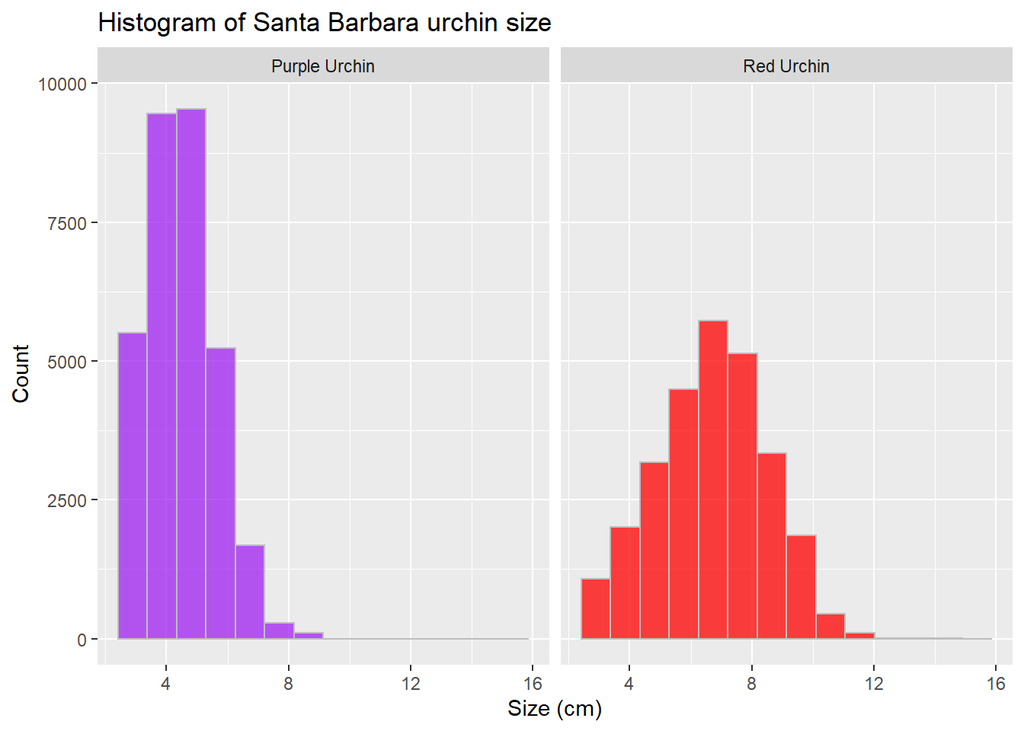

```r
ggplot(data = urchins) +
  geom_histogram(aes(x = size, fill = common_name), alpha = 0.75, bins = 14, color = "gray") +
  facet_wrap(~common_name) + # separate histogram plots for each common name
  labs(x = "Size (cm)", y = "Count", title = "Histogram of Santa Barbara urchin size") + # rename axes
  theme(legend.position = "none") + # remove legend
  scale_fill_manual(values = c("purple", "red")) # fill color for urchin color
```

### Data visualization: Boxplot

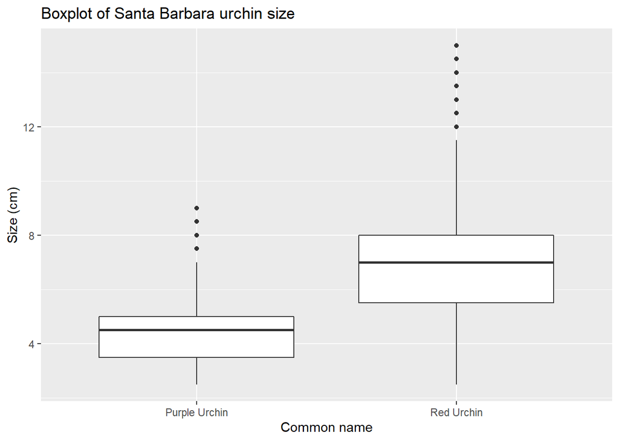

```r
ggplot(data = urchins) +
  geom_boxplot(aes(x = common_name, y = size)) +
  labs(x = "Common name", y = "Size (cm)", title = "Boxplot of Santa Barbara urchin size") # update axis labels
```

### Descriptive statistics table

A summary table to include **mean, median, standard deviation, and sample size** for purple and red urchin data.

```r
urchins_summary <- urchins %>%
  group_by(common_name) %>%
  summarize(mean_size = mean(size, na.rm = T), # calculate mean, median, sd, n
            median_size = median(size, na.rm = T),
            standard_deviation = sd(size, na.rm = T),
            sample_size = n())

kbl(urchins_summary, caption = "Urchin Summary Table", # create summary table
    col.names = c("Common name", # rename column names
                  "Mean size (cm)",
                  "Median size (cm)",
                  "Standard deviation",
                  "Sample size")) %>%
  kable_styling(full_width = FALSE, "bordered")
```

Urchin Summary Table

| Common name | Mean size (cm) | Median size (cm) | Standard deviation | Sample size |
| --- | --- | --- | --- | --- |
| Purple Urchin | 4.469797 | 4.5 | 1.175264 | 31805 |
| Red Urchin | 6.776489 | 7.0 | 1.891343 | 27408 |

### Calculating the percent difference of means

Create a function for percent difference and actual difference

```r
pct_dif <- function(a,b){(b-a)/((a+b)/2)}
actual_dif<-function(a,b){b-a}

pct_dif(a = 4.469797, b = 6.776489)
```

```
## [1] 0.410214
```

```r
actual_dif(a = 4.469797, b = 6.776489)
```

```
## [1] 2.306692
```

### Overall takeaways on sizes between the two urchin species

- The distribution of the red urchin is mostly normal and symmetric with measures of central tendency for the size data of 6.78 for the mean and 7.0 for the median.
- The purple urchin distribution is slightly positively skewed and more leptokurtic based on the exploratory plots.
- Overall, the red urchin sample has a larger mean size than the purple urchin, 6.78cm vs. 4.47cm respectively.
- The mean size of the red urchins is 2.31cm greater than that of the purple urchin (actual mean difference) and there is a 41.02% difference of means. Both of these values are calculated above.
- The histogram plots and boxplots suggest that the red urchin data is more widely dispersed than that of the purple urchin. This is also observed in the summary table with standard deviation values. The purple urchin sample has a smaller standard deviation (1.18 vs. 1.89 for red) and therefore has a narrower data spread with more values closer to the mean. The histogram displays the narrower spread with the high number of observations for the bins around the mean size. The red urchin sample has a standard deviation closer to 2 and displays a wider, or squattier distribution.

## Section 2. Exploring purple urchin counts by site and year

Creating a subset for purple urchins for exploration, visualization, and analysis

```r
purple_urchins <- urchins %>%
  filter(common_name == "Purple Urchin") %>% # include only purple urchins
  mutate(date = mdy(date)) %>% # convert the date to class "Date"
           mutate(year = year(date)) %>% # creating a column with year
  mutate(site_full = case_when( # creating a new column with full names of sites
    site %in% c("NAPL") ~ "Naples Reef",
    site %in% c("AQUE") ~ "Arroyo Quemado Reef",
    site %in% c("IVEE") ~ "Isla Vista Reek",
    site %in% c("CARP") ~ "Carpinteria Reef",
    site %in% c("MOHK") ~ "Mohawk Reef"))
```

### A summary table containing the **total number of purple urchins observed by site and year**

```r
purple_urchins_summary <- purple_urchins %>%
  select("year", "site_full") %>%
  filter(!is.na(year)) %>% # filter out all rows where year is na
  count(site_full, year) # count() combines group_by and summarize

kbl(purple_urchins_summary, caption = "Purple urchin count by site and year", # create a summary table
    col.names = c("Site", "Year", "Number observed")) %>%
  kable_styling(full_width = TRUE, "bordered")
```

Purple urchin count by site and year

| Site | Year | Number observed |
| --- | --- | --- |
| Arroyo Quemado Reef | 2008 | 67 |
| Arroyo Quemado Reef | 2009 | 926 |
| Arroyo Quemado Reef | 2010 | 921 |
| Arroyo Quemado Reef | 2011 | 887 |
| Arroyo Quemado Reef | 2012 | 764 |
| Arroyo Quemado Reef | 2013 | 434 |
| Arroyo Quemado Reef | 2014 | 410 |
| Arroyo Quemado Reef | 2015 | 400 |
| Arroyo Quemado Reef | 2016 | 342 |
| Arroyo Quemado Reef | 2017 | 406 |
| Arroyo Quemado Reef | 2018 | 408 |
| Arroyo Quemado Reef | 2019 | 404 |
| Arroyo Quemado Reef | 2020 | 98 |
| Carpinteria Reef | 2008 | 265 |
| Carpinteria Reef | 2009 | 1315 |
| Carpinteria Reef | 2010 | 930 |
| Carpinteria Reef | 2011 | 1118 |
| Carpinteria Reef | 2012 | 743 |
| Carpinteria Reef | 2013 | 400 |
| Carpinteria Reef | 2014 | 415 |
| Carpinteria Reef | 2015 | 430 |
| Carpinteria Reef | 2016 | 423 |
| Carpinteria Reef | 2017 | 404 |
| Carpinteria Reef | 2018 | 474 |
| Carpinteria Reef | 2019 | 466 |
| Carpinteria Reef | 2020 | 130 |
| Isla Vista Reek | 2012 | 797 |
| Isla Vista Reek | 2013 | 370 |
| Isla Vista Reek | 2014 | 436 |
| Isla Vista Reek | 2015 | 402 |
| Isla Vista Reek | 2016 | 372 |
| Isla Vista Reek | 2017 | 362 |
| Isla Vista Reek | 2018 | 416 |
| Isla Vista Reek | 2019 | 299 |
| Isla Vista Reek | 2020 | 100 |
| Mohawk Reef | 2008 | 294 |
| Mohawk Reef | 2009 | 1344 |
| Mohawk Reef | 2010 | 923 |
| Mohawk Reef | 2011 | 958 |
| Mohawk Reef | 2012 | 856 |
| Mohawk Reef | 2013 | 399 |
| Mohawk Reef | 2014 | 440 |
| Mohawk Reef | 2015 | 418 |
| Mohawk Reef | 2016 | 402 |
| Mohawk Reef | 2017 | 434 |
| Mohawk Reef | 2018 | 459 |
| Mohawk Reef | 2019 | 369 |
| Mohawk Reef | 2020 | 134 |
| Naples Reef | 2008 | 246 |
| Naples Reef | 2009 | 1064 |
| Naples Reef | 2010 | 942 |
| Naples Reef | 2011 | 883 |
| Naples Reef | 2012 | 738 |
| Naples Reef | 2013 | 357 |
| Naples Reef | 2014 | 368 |
| Naples Reef | 2015 | 430 |
| Naples Reef | 2016 | 384 |
| Naples Reef | 2017 | 393 |
| Naples Reef | 2018 | 462 |
| Naples Reef | 2019 | 474 |
| Naples Reef | 2020 | 100 |

### An exploratory graph of counts of purple urchins recorded at each site for the years included in the study (2008-2020)

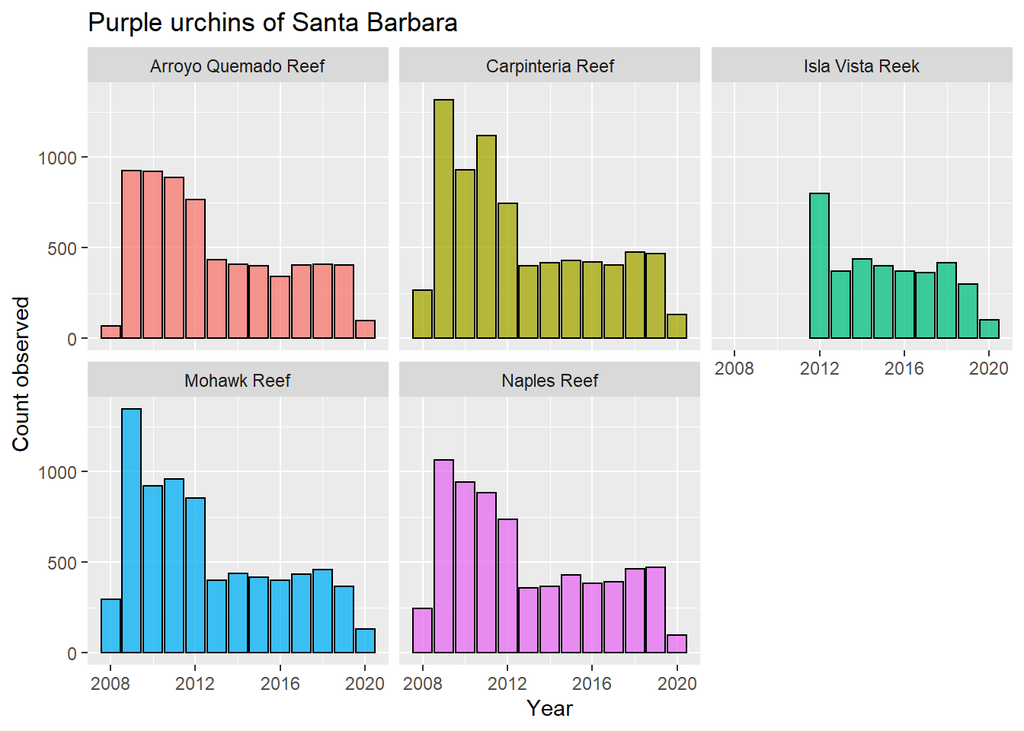

```r
ggplot(data = purple_urchins_summary) +
  geom_col(aes(x = year, y = n, fill = site_full),
           color = "black", alpha = .75, bins = 30) + # fill each site different color, outline in black
  facet_wrap(~site_full) + # create different bar graphs for each site
  scale_x_continuous(breaks = seq(2008, 2020, by = 4)) + # years on x axis labeled every 4 years
  theme(legend.position = "none") +
  labs(x = "Year", y = "Count observed", title = "Purple urchins of Santa Barbara")
```

These barplots are separated by the five site locations and they are an effective manner of showing the count of urchins observed at each year from 2008-2020.